# Introduction

Monika Peteva Petkova

mpetevap@uni-sofia.bg, monikapetevapetkova@gmail.com

2021

# Course Info

### Components

- Lectures
- Exercises
- Lab Exercises

### Lab Exercises Program

- Saturday
  - 9 -11
  - 11-13

### How to pass

**You have to successfully pass all the 3 components !!!**

For the Lab exercises you will have:

- **Exam** in the session
  - Exam is passed if you have more than **3.00**

# Syllabus

| **Introduction to R** |
| --- |
| **Statistics** |
| **Univariate data** |
| **Bivariate data** |
| **Multivariate data** |
| **Discrete random data** |
| **Continuous random data** |
| **Law of large numbers (LLM) and central limit theorem (CLT)** |
| **Confidence interval estimation** |
| **Hypothesis testing** |
| **Two-sample tests** |
| **Chi square tests** |
| **Regression analysis** |
| **Multiple linear regression** |
| **Analysis of variance** |

# Materials

- **Book**: [Verzani, John *Simple R*](https://cran.r-project.org/doc/contrib/Verzani-SimpleR.pdf)
- **Course Web Site**: [moodle](https://learn.fmi.uni-sofia.bg/course/view.php?id=7590)
- **Software**: [R](https://cran.r-project.org/)
- **IDE**: [R Studio](https://www.rstudio.com/)

# Why we learn statistics with R?

R:

- is free and open-source programming language
- runs on UNIX, Windows and Macintosh
- is widely used in academia
- is interactive /results can be seen one command at a time/
- has an excellent built-in help system
- is powerful and easy to learn
- has many built in statistical functions

# Why is it called R?

- Created in Aug 1993 by Ross Ihaka and Robert Gentleman at the University of Auckland, New Zealand
- There was a language called S created by John Chambers in 1976, at Bell Labs
- So the name R came from the first letters of the names of the creators of the language and as a play with the name of S

# R Console

You can download and install R from [here](https://ftp.uni-sofia.bg/CRAN/).  
If you have any problem with the installation you can refer to: for the [Windows users](https://www.youtube.com/watch?v=KKkP8PQ2n_s&ab_channel=EasyTechStudios), for the [Ubuntu users](https://www.youtube.com/watch?v=quna6Cxe4YU&ab_channel=EasyTechStudios), for the [Mac users](https://www.youtube.com/watch?v=EmZqlcKkJMM&ab_channel=EmilyMerchant).

After the installation you must see something similar to this:

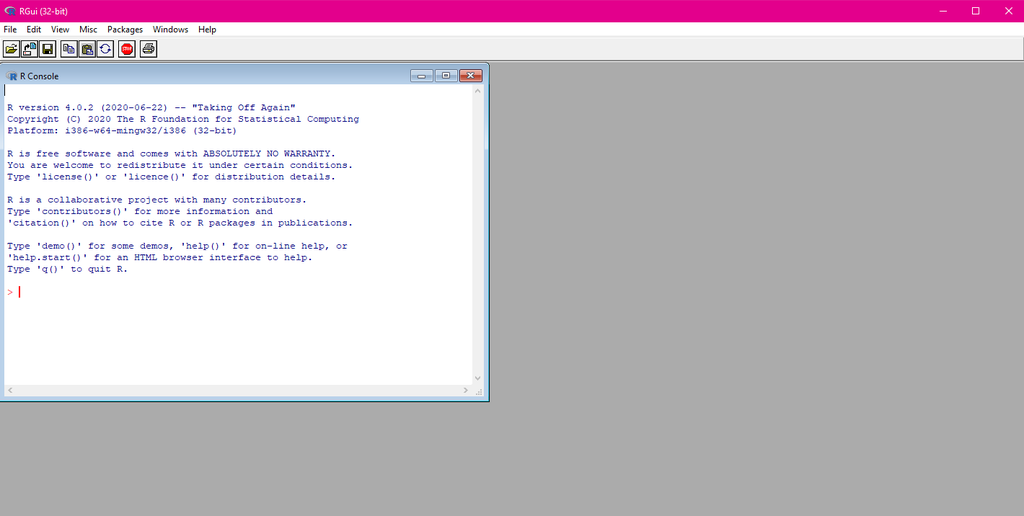

Commands are written after the prompt `>`. If a command is too long to fit on a line, a `+` is used for the continuation prompt.

Shortcuts:

- Enter - run a command
- Up Arrow - give the previous written command
- Esc - interrupt a command

# R Studio

After installing R, you can install the free version of R Studio IDE from [here](https://rstudio.com/products/rstudio/download/).  
If you have any problems with the installation you can refer to : for the [Windows users](https://www.youtube.com/watch?v=9Jo9lJFOf9E&ab_channel=EasyTechStudios), for the [Ubuntu users](https://www.youtube.com/watch?v=tMwaDXqv4W4&ab_channel=EasyTechStudios), for the [Mac users](https://www.youtube.com/watch?v=EmZqlcKkJMM&ab_channel=EmilyMerchant).

After the installation you must see something similar to this:

[figure not shown]

R Studio is customizable, but in the begging the interface is separated in 4 panels in which we have:

- Upper Left panel
  - **Text editor** - here you write your code
- Lower Left panel
  - **Console** - the commands are executed here and the output is printed
- Upper Right panel
  - **Environment** - contains interactive list of loaded R objects
  - **History** - containing the executed commands
- Lower Right panel
  - **Files** - shows the files in your working directory
  - **Plots** - output location for plots
  - **Packages** - list of installed packages
  - **Help** - output location for help commands and help search window

Shortcuts

- Ctrl + Shift + N - Open new R script
- Ctrl + Enter - Run current line
- Ctrl + Shift + S - Run an entire file of code
- Ctrl + Z - Undo
- Ctrl + Shift + Z - Redo
- Ctrl + D - Delete Line
- Ctrl + 1 - Moves the cursor to the text editor area
- Ctrl + 2 - Moves the cursor to the console area
- Alt + Shift + K - Shows keyboard shortcut reference

Open a new project and a new R script.